# SageMaker Ground Truth and Object Detection

## Workshop Guide

### Bootstrap embedded images

Download images used in the rest of this guide

```python
%%time
import sagemaker
from sagemaker import get_execution_role

role = get_execution_role()
print(role)
sess = sagemaker.Session()
BUCKET = sess.default_bucket()
PREFIX = 'input'
print(BUCKET)
```

```
arn:aws:iam::168402291854:role/service-role/AmazonSageMaker-ExecutionRole-20210419T123840
sagemaker-us-east-1-168402291854
CPU times: user 951 ms, sys: 163 ms, total: 1.11 s
Wall time: 7.7 s
```

## Introduction to dataset

In this workshop we will use a dataset from the inaturalist.org This dataset contains 500 images of bees that have been uploaded by inaturalist users for the purposes of recording the observation and identification. We only used images that their users have licensed under [CC0](https://creativecommons.org/share-your-work/public-domain/cc0/) license. For your convenience, we have placed the dataset in S3 in a single zip archive here: http://aws-tc-largeobjects.s3-us-west-2.amazonaws.com/DIG-TF-200-MLBEES-10-EN/dataset.zip

First, download and unzip the archive.

```python
!wget http://aws-tc-largeobjects.s3-us-west-2.amazonaws.com/DIG-TF-200-MLBEES-10-EN/dataset.zip
!unzip -qo dataset.zip
```

```
--2021-04-19 10:44:32--  http://aws-tc-largeobjects.s3-us-west-2.amazonaws.com/DIG-TF-200-MLBEES-10-EN/dataset.zip
Resolving aws-tc-largeobjects.s3-us-west-2.amazonaws.com (aws-tc-largeobjects.s3-us-west-2.amazonaws.com)... 52.218.183.114
Connecting to aws-tc-largeobjects.s3-us-west-2.amazonaws.com (aws-tc-largeobjects.s3-us-west-2.amazonaws.com)|52.218.183.114|:80... connected.
HTTP request sent, awaiting response... 200 OK
Length: 70375947 (67M) [application/x-zip-compressed]
Saving to: ‘dataset.zip’

dataset.zip         100%[===================>]  67.12M  11.6MB/s    in 6.4s

2021-04-19 10:44:39 (10.5 MB/s) - ‘dataset.zip’ saved [70375947/70375947]
```

The archive contains the following structure: 500 `.jpg` image files, a manifest file (to be explained later) and 10 test images in the `test` subfolder.

```python
!unzip -l dataset.zip | tail -20
```

```
   251027  05-15-2019 19:21   9530124.jpg
   110561  05-15-2019 19:21   9542264.jpg
   312354  05-15-2019 19:21   9543188.jpg
    76903  05-15-2019 19:21   9637165.jpg
    48663  05-15-2019 19:21   9765741.jpg
    66393  05-15-2019 19:21   9787032.jpg
   273392  05-22-2019 21:58   output.manifest
        0  06-01-2019 05:51   test/
    83438  06-01-2019 05:51   test/22427594.jpg
   152133  06-01-2019 05:51   test/22469656.jpg
   205930  06-01-2019 05:51   test/22544384.jpg
   137755  06-01-2019 05:51   test/22673445.jpg
   124565  06-01-2019 05:51   test/22741822.jpg
    39502  06-01-2019 05:51   test/22774999.jpg
    39086  06-01-2019 05:51   test/22775000.jpg
   149389  06-01-2019 05:51   test/22901964.jpg
   103322  06-01-2019 05:51   test/22971237.jpg
   109178  06-01-2019 05:51   test/23086755.jpg
---------                     -------
 70635014                     512 files
```

```python
!aws s3 sync --exclude="*" --include="[0-9]*.jpg" . s3://$BUCKET/$PREFIX/
```

[output not shown]

[output cut: 446 more lines]

[output not shown]

## Reviewing labeling results

```python
# provided labeling results
labeling_job_name = 'bees-500'
augmented_manifest_file = 'output.manifest'
```

Let's see the first few lines of the manifest file

```python
#replacing bucket name and prefix to right format
outputManifest = open("output.manifest", "rt")
#read file contents to string
manifest = outputManifest.read()
#replace all occurrences of the required string
replaceStr = BUCKET + '/' + PREFIX
manifest = manifest.replace('sagemaker-remars/datasets/na-bees/500', replaceStr)
#close the input file
outputManifest.close()
#open the input file in write mode
outputManifest = open("output.manifest", "wt")
#overrite the input file with the resulting data
outputManifest.write(manifest)
#close the file
outputManifest.close()
```

```python
!head -3 $augmented_manifest_file
```

```
{"source-ref":"s3://sagemaker-us-east-1-168402291854/input/10006450.jpg","bees-500":{"annotations":[{"class_id":0,"width":95.39999999999998,"top":256.2,"height":86.80000000000001,"left":177}],"image_size":[{"width":500,"depth":3,"height":500}]},"bees-500-metadata":{"job-name":"labeling-job/bees-500"…
{"source-ref":"s3://sagemaker-us-east-1-168402291854/input/10022723.jpg","bees-500":{"annotations":[{"class_id":0,"width":93.8,"top":228.8,"height":135,"left":126.8}],"image_size":[{"width":375,"depth":3,"height":500}]},"bees-500-metadata":{"job-name":"labeling-job/bees-500","class-map":{"0":"bee"},…
{"source-ref":"s3://sagemaker-us-east-1-168402291854/input/10059108.jpg","bees-500":{"annotations":[{"class_id":0,"width":157.39999999999998,"top":188.60000000000002,"height":131.2,"left":110.8}],"image_size":[{"width":375,"depth":3,"height":500}]},"bees-500-metadata":{"job-name":"labeling-job/bees-…
```

Now let's plot all the annotated images. First, let's define a function that displays the local image file and draws over it the bounding boxes obtained via labeling.

```python
import os
import boto3
import matplotlib.pyplot as plt
import matplotlib.patches as patches
from PIL import Image
import numpy as np
from itertools import cycle

def show_annotated_image(img_path, bboxes):
    im = np.array(Image.open(img_path), dtype=np.uint8)

    # Create figure and axes
    fig,ax = plt.subplots(1)

    # Display the image
    ax.imshow(im)

    colors = cycle(['r', 'g', 'b', 'y', 'c', 'm', 'k', 'w'])

    for bbox in bboxes:
        # Create a Rectangle patch
        rect = patches.Rectangle((bbox['left'],bbox['top']),bbox['width'],bbox['height'],linewidth=1,edgecolor=next(colors),facecolor='none')

        # Add the patch to the Axes
        ax.add_patch(rect)

    plt.show()
```

Next, read the augmented manifest (JSON lines format) line by line and display the first 10 images.

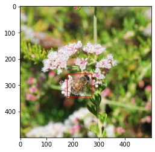

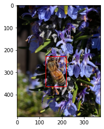

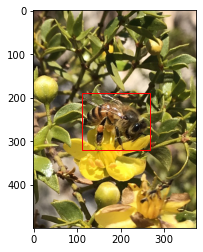

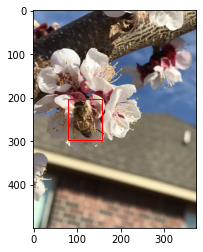

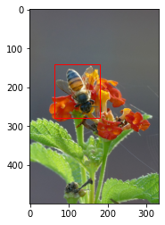

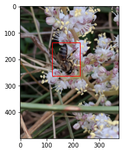

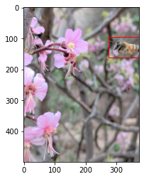

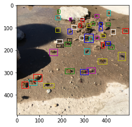

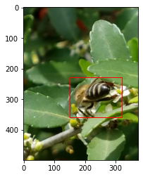

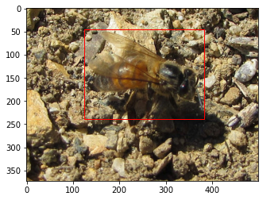

```python
!pip -q install --upgrade pip
!pip -q install jsonlines
import jsonlines
from itertools import islice

with jsonlines.open(augmented_manifest_file, 'r') as reader:
    for desc in islice(reader, 10):
        img_url = desc['source-ref']
        img_file = os.path.basename(img_url)
        file_exists = os.path.isfile(img_file)

        bboxes = desc[labeling_job_name]['annotations']
        show_annotated_image(img_file, bboxes)
```

## Training an Object Detection Model

We are now ready to use the labeled dataset in order to train a Machine Learning model using the SageMaker [built-in Object Detection algorithm](https://docs.aws.amazon.com/sagemaker/latest/dg/object-detection.html).

For this, we would need to split the full labeled dataset into a training and a validation datasets. Out of the total of 500 images we are going to use 400 for training and 100 for validation. The algorithm will use the first one to train the model and the latter to estimate the accuracy of the model, trained so far. The augmented manifest file from the previously run full labeling job was included in the original zip archive as `output.manifest`.

```python
import json

with jsonlines.open('output.manifest', 'r') as reader:
    lines = list(reader)
    # Shuffle data in place.
    np.random.shuffle(lines)

dataset_size = len(lines)
num_training_samples = round(dataset_size*0.8)

train_data = lines[:num_training_samples]
validation_data = lines[num_training_samples:]

augmented_manifest_filename_train = 'train.manifest'

with open(augmented_manifest_filename_train, 'w') as f:
    for line in train_data:
        f.write(json.dumps(line))
        f.write('\n')

augmented_manifest_filename_validation = 'validation.manifest'

with open(augmented_manifest_filename_validation, 'w') as f:
    for line in validation_data:
        f.write(json.dumps(line))
        f.write('\n')

print(f'training samples: {num_training_samples}, validation samples: {len(lines)-num_training_samples}')
```

```
training samples: 400, validation samples: 100
```

Next, let's upload the two manifest files to S3 in preparation for training. We will use the same bucket you created earlier.

```python
pfx_training = PREFIX + '/training' if PREFIX else 'training'
# Defines paths for use in the training job request.
s3_train_data_path = 's3://{}/{}/{}'.format(BUCKET, pfx_training, augmented_manifest_filename_train)
s3_validation_data_path = 's3://{}/{}/{}'.format(BUCKET, pfx_training, augmented_manifest_filename_validation)

!aws s3 cp train.manifest s3://$BUCKET/$pfx_training/
!aws s3 cp validation.manifest s3://$BUCKET/$pfx_training/
```

```
upload: ./train.manifest to s3://sagemaker-us-east-1-168402291854/input/training/train.manifest
upload: ./validation.manifest to s3://sagemaker-us-east-1-168402291854/input/training/validation.manifest
```

We need the Amazon SageMaker Object Detection docker image

```python
import time
import sagemaker

role = sagemaker.get_execution_role()
sess = sagemaker.Session()

training_image = sagemaker.amazon.amazon_estimator.get_image_uri(
    boto3.Session().region_name, 'object-detection', repo_version='latest')

s3_output_path = 's3://{}/{}/output'.format(BUCKET, pfx_training)

# Create job name
training_job_name = 'bees-objectdetection-resnet'
```

```
The method get_image_uri has been renamed in sagemaker>=2.
See: https://sagemaker.readthedocs.io/en/stable/v2.html for details.
Defaulting to the only supported framework/algorithm version: 1. Ignoring framework/algorithm version: latest.
```

```python
object_detection_params = \
    {
        "AlgorithmSpecification": {

            "TrainingImage": training_image,
            "TrainingInputMode": "Pipe"
        },
        "RoleArn": role,
        "OutputDataConfig": {
            "S3OutputPath": s3_output_path
        },
        "ResourceConfig": {
            "InstanceCount": 1,
            "InstanceType": "ml.p3.2xlarge",
            "VolumeSizeInGB": 1
        },
        "TrainingJobName": training_job_name,
        "HyperParameters": {
            "base_network": "resnet-50",
            "use_pretrained_model": "1",
            "num_classes": "1",
            "mini_batch_size": "1",
            "epochs": "100",
            "learning_rate": "0.001",
            "lr_scheduler_step": "",
            "lr_scheduler_factor": "0.1",
            "optimizer": "sgd",
            "momentum": "0.9",
            "weight_decay": "0.0005",
            "overlap_threshold": "0.5",
            "nms_threshold": "0.45",
            "image_shape": "300",
            "label_width": "350",
            "num_training_samples": str(num_training_samples),
            "early_stopping":"True",
            "early_stopping_min_epochs": "50",
            "early_stopping_patience": "5",
            "early_stopping_tolerance": "0.01"
        },
            "StoppingCondition": {
                "MaxRuntimeInSeconds": 43200

        },
        "InputDataConfig": [
            {
                "ChannelName": "train",
                "DataSource": {
                    "S3DataSource": {
                        "S3DataType": "AugmentedManifestFile",
                        "S3Uri": s3_train_data_path,
                        "S3DataDistributionType": "FullyReplicated",
                        "AttributeNames": ['source-ref', 'bees-500']
                    }
                },
                "ContentType": "application/x-recordio",
                "RecordWrapperType": "RecordIO",
                "CompressionType": "None"
            },
            {
                "ChannelName": "validation",
                "DataSource": {
                    "S3DataSource": {
                        "S3DataType": "AugmentedManifestFile",
                        "S3Uri": s3_validation_data_path,
                        "S3DataDistributionType": "FullyReplicated",
                        "AttributeNames": ['source-ref', 'bees-500']
                    }
                },
                "ContentType": "application/x-recordio",
                "RecordWrapperType": "RecordIO",
                "CompressionType": "None"
            }
        ]
    }
```

```python
# # Or we can use the following cell to launch the training job

# # Create a train and validation data channel with S3_data_type as 'AugmentedManifestFile' and attribute names.
# training_data = sagemaker.session.s3_input(
#                                         s3_train_data_path,
#                                         distribution='FullyReplicated',
#                                         content_type='application/x-recordio',
#                                         s3_data_type='AugmentedManifestFile',
#                                         attribute_names=['source-ref', 'bees-500'],
#                                         record_wrapping='RecordIO')

# validation_data = sagemaker.session.s3_input(
#                                         s3_validation_data_path,
#                                         distribution='FullyReplicated',
#                                         content_type='application/x-recordio',
#                                         s3_data_type='AugmentedManifestFile',
#                                         attribute_names=['source-ref', 'bees-500'],
#                                         record_wrapping='RecordIO')

# data_channels = {'train': training_data, 'validation': validation_data}

# object_detection_model = sagemaker.estimator.Estimator(training_image,
#                                          role,
#                                          train_instance_count=1,
#                                          train_instance_type='ml.p3.2xlarge',
#                                          train_volume_size = 1,
#                                          train_max_run = 360000,
#                                          input_mode= 'Pipe',
#                                          output_path=s3_output_path,
#                                          sagemaker_session=sess)

# object_detection_model.set_hyperparameters(base_network='resnet-50',
#                              use_pretrained_model=1,
#                              num_classes=1,
#                              mini_batch_size=1,
#                              epochs=100,
#                              learning_rate=0.001,
#                              lr_scheduler_step='',
#                              lr_scheduler_factor=0.1,
#                              optimizer='sgd',
#                              momentum=0.9,
#                              weight_decay=0.0005,
#                              overlap_threshold=0.5,
#                              nms_threshold=0.45,
#                              image_shape=300,
#                              label_width=100,
#                              num_training_samples=len(num_training_samples),
#                              early_stopping=True,
#                              early_stopping_min_epochs= 50,
#                              early_stopping_patience= 5,
#                              early_stopping_tolerance= 0.01
#                             )

# object_detection_model.fit(inputs=data_channels, logs=True)
```

```python
# Now we create the SageMaker training job.
client = boto3.client('sagemaker')
client.create_training_job(**object_detection_params)
```

```
{'TrainingJobArn': 'arn:aws:sagemaker:us-east-1:168402291854:training-job/bees-objectdetection-resnet',
 'ResponseMetadata': {'RequestId': '63d6ee60-0f4e-459b-a5be-a2b76d72365f',
  'HTTPStatusCode': 200,
  'HTTPHeaders': {'x-amzn-requestid': '63d6ee60-0f4e-459b-a5be-a2b76d72365f',
   'content-type': 'application/x-amz-json-1.1',
   'content-length': '102',
   'date': 'Mon, 19 Apr 2021 10:48:14 GMT'},
  'RetryAttempts': 0}}
```

```python
# Confirm that the training job has started
training_info = client.describe_training_job(TrainingJobName=training_job_name)

print("Training job status: ", training_info['TrainingJobStatus'])
print("Secondary status: ", training_info['SecondaryStatus'])
```

```
Training job status:  Completed
Secondary status:  Completed
```

## Review of Training Results

First, let's create the SageMaker model out of model artifacts

```python
import time
timestamp = time.strftime('-%Y-%m-%d-%H-%M-%S', time.gmtime())
model_name = training_job_name + '-model' + timestamp

training_image = training_info['AlgorithmSpecification']['TrainingImage']
model_data = training_info['ModelArtifacts']['S3ModelArtifacts']

primary_container = {
    'Image': training_image,
    'ModelDataUrl': model_data,
}

from sagemaker import get_execution_role

role = get_execution_role()

create_model_response = client.create_model(
    ModelName = model_name,
    ExecutionRoleArn = role,
    PrimaryContainer = primary_container)

print(create_model_response['ModelArn'])
```

```
arn:aws:sagemaker:us-east-1:168402291854:model/bees-objectdetection-resnet-model-2021-04-19-11-14-00
```

```python
timestamp = time.strftime('-%Y-%m-%d-%H-%M-%S', time.gmtime())
endpoint_config_name = training_job_name + '-epc' + timestamp
endpoint_config_response = client.create_endpoint_config(
    EndpointConfigName = endpoint_config_name,
    ProductionVariants=[{
        'InstanceType':'ml.t2.medium',
        'InitialInstanceCount':1,
        'ModelName':model_name,
        'VariantName':'AllTraffic'}])

print('Endpoint configuration name: {}'.format(endpoint_config_name))
print('Endpoint configuration arn:  {}'.format(endpoint_config_response['EndpointConfigArn']))
```

```
Endpoint configuration name: bees-objectdetection-resnet-epc-2021-04-19-11-14-13
Endpoint configuration arn:  arn:aws:sagemaker:us-east-1:168402291854:endpoint-config/bees-objectdetection-resnet-epc-2021-04-19-11-14-13
```

### Create Endpoint

The next cell creates an endpoint that can be validated and incorporated into production applications. This takes about 10 minutes to complete.

```python
timestamp = time.strftime('-%Y-%m-%d-%H-%M-%S', time.gmtime())
endpoint_name = training_job_name + '-ep' + timestamp
print('Endpoint name: {}'.format(endpoint_name))

endpoint_params = {
    'EndpointName': endpoint_name,
    'EndpointConfigName': endpoint_config_name,
}
endpoint_response = client.create_endpoint(**endpoint_params)
print('EndpointArn = {}'.format(endpoint_response['EndpointArn']))
```

```
Endpoint name: bees-objectdetection-resnet-ep-2021-04-19-11-15-00
EndpointArn = arn:aws:sagemaker:us-east-1:168402291854:endpoint/bees-objectdetection-resnet-ep-2021-04-19-11-15-00
```

```python
# get the status of the endpoint
response = client.describe_endpoint(EndpointName=endpoint_name)
status = response['EndpointStatus']
print('EndpointStatus = {}'.format(status))
```

```
EndpointStatus = InService
```

### Perform inference

We will invoke the deployed endpoint to detect bees in the 10 test images that were inside the `test` folder in `dataset.zip` which you downloaded at the beginning of the workshop.

```python
import glob
test_images = glob.glob('test/*')
print(*test_images, sep="\n")
```

```
test/22971237.jpg
test/22741822.jpg
test/22427594.jpg
test/22774999.jpg
test/22901964.jpg
test/22469656.jpg
test/22673445.jpg
test/22544384.jpg
test/22775000.jpg
test/23086755.jpg
```

Next, define a function that converts the prediction array returned by our endpoint to the bounding box structure expected by our image display function.

```python
def prediction_to_bbox_data(image_path, prediction):
    class_id, confidence, xmin, ymin, xmax, ymax = prediction
    width, height = Image.open(image_path).size
    bbox_data = {'class_id': class_id,
               'height': (ymax-ymin)*height,
               'width': (xmax-xmin)*width,
               'left': xmin*width,
               'top': ymin*height}
    return bbox_data
```

Finally, for each of the test images, the following cell transforms the image into the appropriate format for realtime prediction, repeatedly calls the endpoint, receives back the prediction, and displays the result.

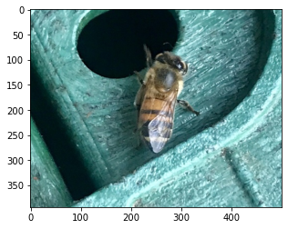

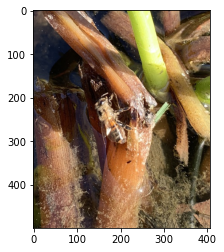

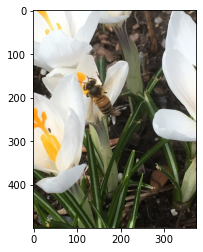

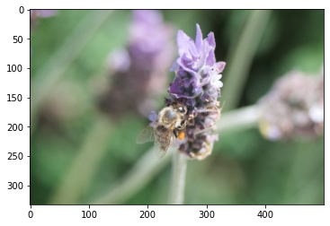

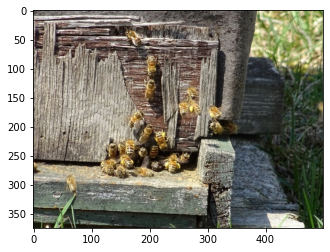

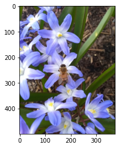

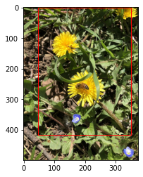

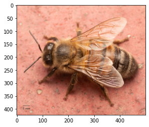

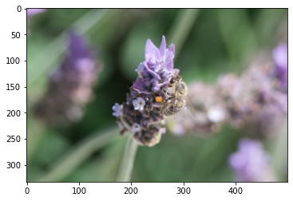

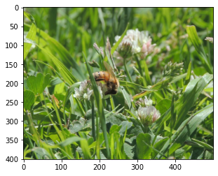

```python
import matplotlib.pyplot as plt

endpoint_name='bees-objectdetection-resnet-ep-2021-04-19-11-15-00'

runtime_client = boto3.client('sagemaker-runtime')

# Call SageMaker endpoint to obtain predictions
def get_predictions_for_img(runtime_client, endpoint_name, img_path):
    with open(img_path, 'rb') as f:
        payload = f.read()
        payload = bytearray(payload)

    response = runtime_client.invoke_endpoint(EndpointName=endpoint_name,
                                       ContentType='application/x-image',
                                       Body=payload)

    result = response['Body'].read()
    result = json.loads(result)
    return result


# wait until the status has changed
client.get_waiter('endpoint_in_service').wait(EndpointName=endpoint_name)
endpoint_response = client.describe_endpoint(EndpointName=endpoint_name)
status = endpoint_response['EndpointStatus']
if status != 'InService':
    raise Exception('Endpoint creation failed.')

for test_image in test_images:
    result = get_predictions_for_img(runtime_client, endpoint_name, test_image)
    confidence_threshold = .5
    best_n = 1
    # display the best n predictions with confidence > confidence_threshold
    predictions = [prediction for prediction in result['prediction'] if prediction[1] > confidence_threshold]
    predictions.sort(reverse=True, key = lambda x: x[1])
    bboxes = [prediction_to_bbox_data(test_image, prediction) for prediction in predictions[:best_n]]
    show_annotated_image(test_image, bboxes)
```

## Cleanup

At the end of the lab we would like to delete the real-time endpoint, as keeping a real-time endpoint around while being idle is costly and wasteful.

```python
client.delete_endpoint(EndpointName=endpoint_name)
```